# Using rockyIntertidal R pkg.

#### plotPITransects()

This function plots bolt distance and elevation data by transect for each park, site, and year.

Plot Ship Harbor transect contours for each transect

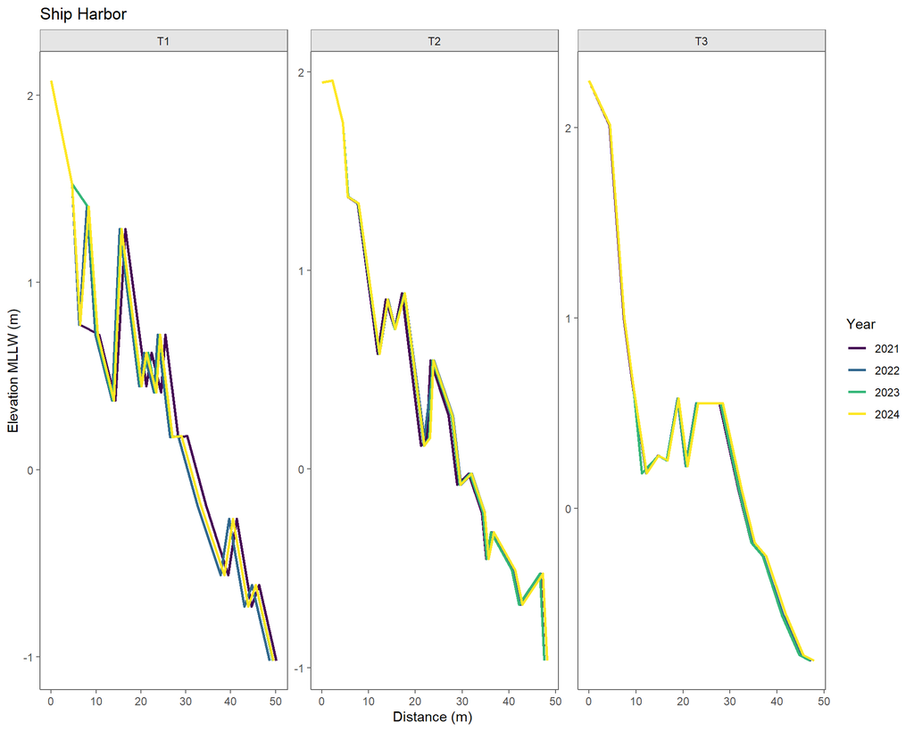

```r
trans_shp <- plotPITransects(site = "SHIHAR", years = 2021:2024)
trans_shp
```

Plot multiple sites in ACAD and fixing the axis scales for context across sites.

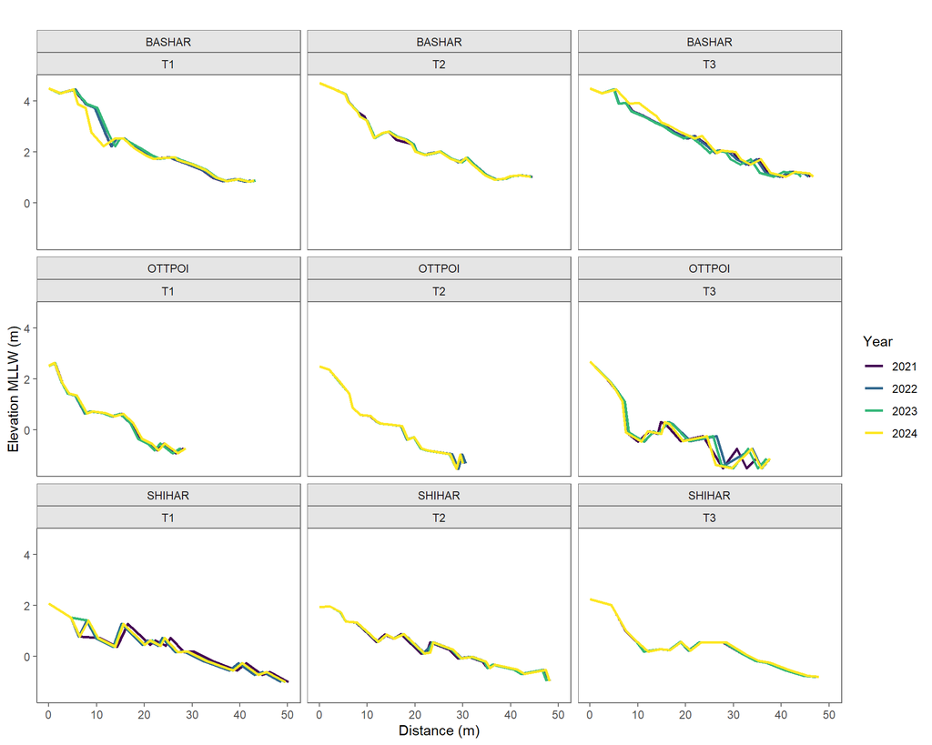

```r
trans3 <- plotPITransects(site = c("BASHAR", "OTTPOI", "SHIHAR"), years = 2021:2024, facet_scales = "fixed")
trans3
```

Plot BOHA and fixing the axis scales for context across sites for all years and add dashed line at MLLW = 0.

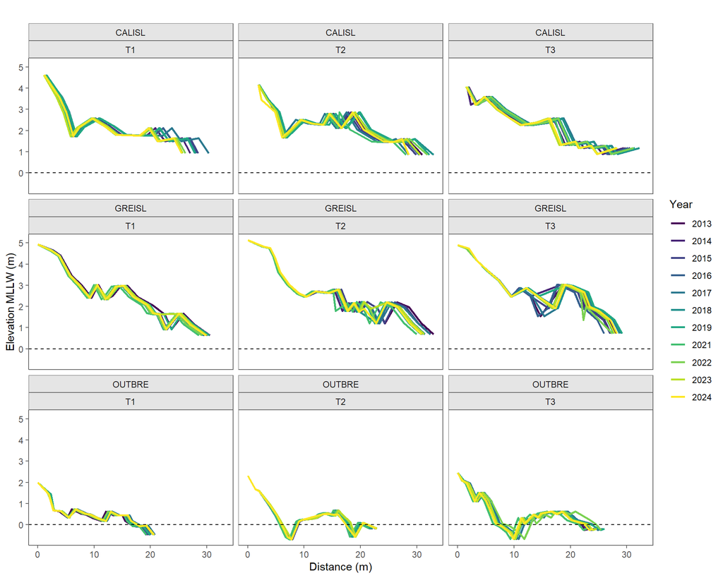

```r
boha_pi <- plotPITransects(park = "BOHA", facet_scales = "fixed") +
  geom_hline(yintercept = 0, linetype = "dashed")
boha_pi
```

#### plotSpeciesContours()

This function plots a loess smoothed contour averaging the transects across all years specified. Point intercept minimum and maximum elevation ranges are plotted along the contours by year for each of the main species groups: REDGRP, ASCNOD, FUCSPP, MUSSPP, BARSPP, NONCOR. Photoplot cover is plotted as median cover and median elevation for each target species plot.

Plot Little Hunter all years.

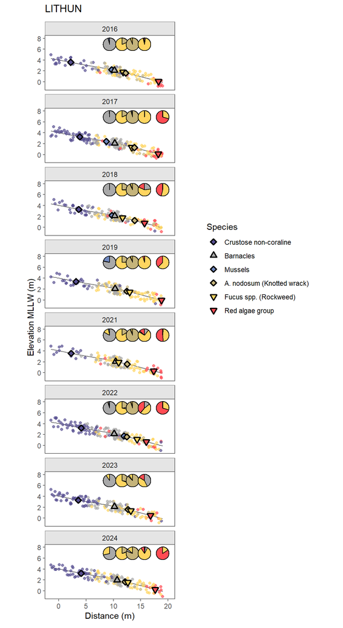

```r
lh_spp <- plotSpeciesContours(site = "LITHUN")
lh_spp
```

Plot Bass Harbor every 3 years since monitoring began.

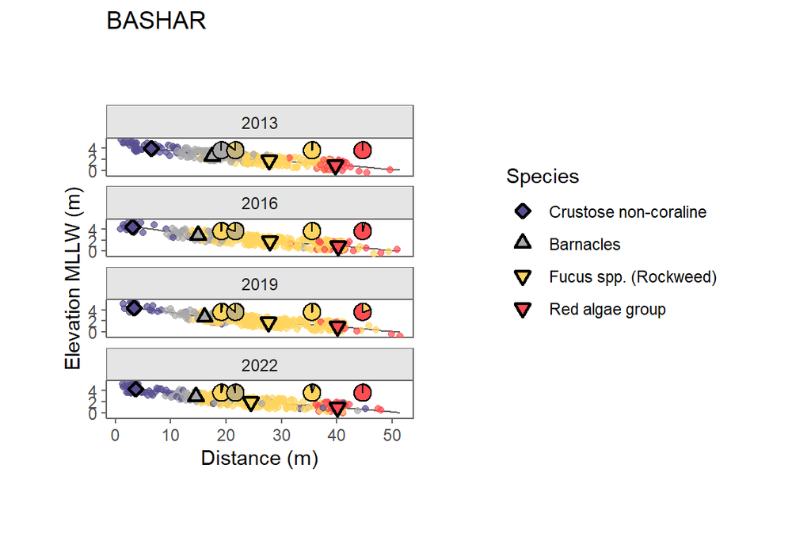

```r
bh_spp <- plotSpeciesContours(site = "BASHAR", years = seq(2013, as.numeric(format(Sys.Date(), "%Y")), 3))
bh_spp
```

Plot Green Island for 2024.

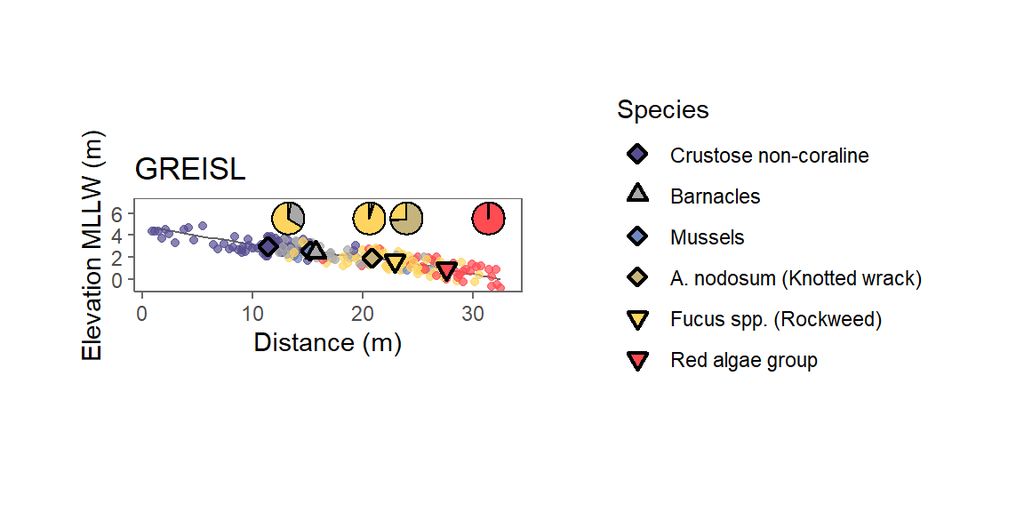

```r
gr_pi <- plotSpeciesContours(site = "GREISL", years = 2024)
gr_pi
```

Plot Green Island for 2024 without photo plot pies.

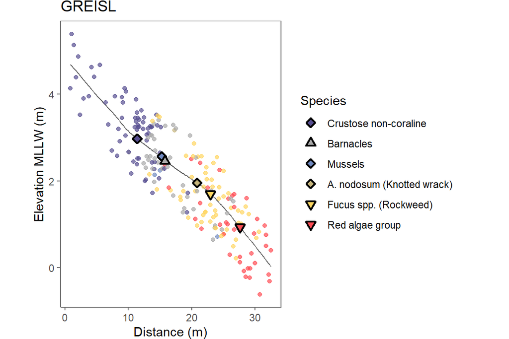

```r
gr_pi2 <- plotSpeciesContours(site = "GREISL", years = 2024, include_photoplots = F)
gr_pi2
```

#### plotWaterTemp()

This function plots water temperature at high tide by site. Note that function works on compiled logger data, rather than working off the raw logger data. Compiled datasets should be imported using importWaterTemp(). To speed up plotting of multiple sites or long time-series, plot the simplified water temperature data derived from importWaterTemp(simplify = TRUE). **Note the data and functions have not been checked recently. Functions in this section not currently active, and were not run for this website.**

Plot logger water temp for 2020:2022 in ACAD sites in 1 facet column.

```r
plotWaterTemp(park = "ACAD", years = 2020:2022, facet_col = 1)
```

Plot water temp in Bass Harbor for 2011:2022.

```r
plotWaterTemp(site = "BASHAR", years = 2011:2022)
```

#### theme_rocky()

This function customizes a theme for plotting data in the package, including removing the default panel grids from ggplot2 figures.

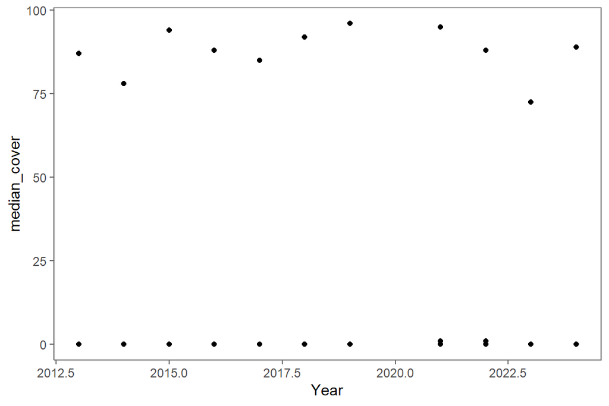

```r
dat <- sumPhotoCover(site = "SHIHAR", community = "Ascophyllum", species = "ASCNOD")

library(ggplot2)
p <-
ggplot(dat, aes(x = Year, y = median_cover)) +
  geom_point() +
  theme_rocky()

p
```